# projet RDSM

Amélie

2025-01-02

**PROJET D’ANALYSE MULTIVARIEE DES POLLUANTS ATMOSPHERIQUES A PERIGUEUX en 2024**

```r
library(tidyr)
library(dplyr)
```

```r
library(ggplot2)
library(lubridate) # pour la gestion des format date
library(MASS)
library(FactoMineR)
library(corrplot)
library(factoextra)
library(plotly)
# manipulation pour les données manquantes
library(naniar)
# si on veut faire de l'ACP en dynamique, ie explorer et voir directement le rendu
library(Factoshiny)
```

Nous allons nous intéresser aux polluants atmosphériques à Périgueux en 2024. Il nous faut tout d’abord nettoyer le fichier et l’adapter à nos besoins

```r
load("ATMO-RDSM.rda")
glimpse(df)
```

```
## Rows: 8,696
## Columns: 28
## $ date_debut             <dttm> 2023-11-08 00:00:00, 2023-11-08 01:00:00, 2023…
## $ date_debut_standard    <dbl> 45238.00, 45238.04, 45238.08, 45238.12, 45238.1…
## $ NO2                    <dbl> 3, 3, 3, 6, 4, 6, 8, 9, 13, 7, 5, 3, 4, 3, 3, 3…
## $ PM2.5                  <dbl> NA, NA, NA, NA, NA, NA, NA, NA, NA, NA, NA, NA,…
## $ O3                     <dbl> 34, 32, 34, 31, 26, 22, 25, 47, 48, 54, 58, 64,…
## $ NO                     <dbl> 3.6, 3.9, 3.4, 5.9, 3.7, 7.1, 9.7, 11.7, 20.3, …
## $ PM10                   <dbl> 11, 11, 10, 10, 12, 12, 12, 9, 10, 10, 9, 8, 9,…
## $ temperature            <dbl> 7.1, 7.5, 8.1, 8.4, 8.6, 8.9, 8.7, 8.9, 9.6, 10…
## $ pression               <dbl> 1018.6, 1018.1, 1018.5, 1018.3, 1018.6, 1018.6,…
## $ pression_variation_3h  <dbl> 0.0, 0.0, 0.0, -0.3, 0.5, 0.1, 0.3, 0.3, 0.5, 0…
## $ humidite               <dbl> 94, 95, 95, 95, 95, 95, 95, 94, 94, 91, 89, 87,…
## $ point_de_rosee         <dbl> 6.1, 6.7, 7.2, 7.8, 7.8, 8.3, 7.8, 8.3, 8.9, 9.…
## $ vent_moyen             <dbl> 0.0, 0.0, 0.0, 0.0, 0.0, 0.0, 0.0, 0.0, 1.6, 3.…
## $ vent_rafales           <dbl> 0, 0, 0, 0, 0, 0, 0, 0, 0, 0, 0, 0, 0, 0, 0, 0,…
## $ vent_rafales_10min     <dbl> 0.0, 0.0, 0.0, 0.0, 0.0, 0.0, 0.0, 0.0, 8.0, 9.…
## $ vent_direction         <dbl> 110, 110, 110, 110, 110, 110, 110, 110, 150, 92…
## $ temperature_min        <dbl> 7.1, 7.1, 7.1, 7.1, 7.1, 7.1, 7.1, 7.1, 7.1, 7.…
## $ temperature_max        <dbl> 7.1, 7.5, 8.1, 8.4, 8.6, 8.9, 8.9, 8.9, 9.6, 10…
## $ pluie_1h               <dbl> 0.0, 0.0, 0.0, 0.0, 0.0, 0.0, 0.0, 0.0, 0.0, 0.…
## $ pluie_3h               <dbl> 0.0, 0.0, 0.0, 0.0, 0.0, 0.0, 0.0, 0.0, 0.0, 0.…
## $ pluie_6h               <dbl> 0.0, 0.0, 0.0, 0.0, 0.0, 0.0, 0.0, 0.0, 0.0, 0.…
## $ pluie_12h              <dbl> 0.6, 0.6, 0.6, 0.6, 0.6, 0.0, 0.0, 0.0, 0.0, 0.…
## $ pluie_24h              <dbl> 1.6, 1.6, 1.2, 0.8, 0.8, 0.8, 0.6, 0.6, 0.6, 0.…
## $ pluie_cumul_0h         <dbl> 0.0, 0.0, 0.0, 0.0, 0.0, 0.0, 0.0, 0.0, 0.0, 0.…
## $ pluie_intensite        <dbl> 0.0, 0.0, 0.0, 0.0, 0.0, 0.0, 0.0, 0.0, 0.0, 0.…
## $ pluie_intensite_max_1h <dbl> 0, 0, 0, 0, 0, 0, 0, 0, 0, 0, 0, 0, 0, 0, 0, 0,…
## $ jour                   <ord> mercredi, mercredi, mercredi, mercredi, mercred…
## $ heure                  <int> 0, 1, 2, 3, 4, 5, 6, 7, 8, 9, 10, 11, 12, 13, 1…
```

```r
print(miss_var_summary(df), n=35)
```

```
## # A tibble: 28 × 3
##    variable               n_miss pct_miss
##    <chr>                   <int>    <num>
##  1 PM2.5                    7955    91.5
##  2 NO2                       545     6.27
##  3 NO                        542     6.23
##  4 PM10                      300     3.45
##  5 date_debut                  0     0
##  6 date_debut_standard         0     0
##  7 O3                          0     0
##  8 temperature                 0     0
##  9 pression                    0     0
## 10 pression_variation_3h       0     0
## 11 humidite                    0     0
## 12 point_de_rosee              0     0
```

[output cut: 16 more lines]

```r
df$PM2.5 <- NULL
print(miss_var_summary(df), n=35)
```

```
## # A tibble: 27 × 3
##    variable               n_miss pct_miss
##    <chr>                   <int>    <num>
##  1 NO2                       545     6.27
##  2 NO                        542     6.23
##  3 PM10                      300     3.45
##  4 date_debut                  0     0
##  5 date_debut_standard         0     0
##  6 O3                          0     0
##  7 temperature                 0     0
##  8 pression                    0     0
##  9 pression_variation_3h       0     0
## 10 humidite                    0     0
## 11 point_de_rosee              0     0
## 12 vent_moyen                  0     0
## 13 vent_rafales                0     0
## 14 vent_rafales_10min          0     0
## 15 vent_direction              0     0
## 16 temperature_min             0     0
## 17 temperature_max             0     0
## 18 pluie_1h                    0     0
## 19 pluie_3h                    0     0
## 20 pluie_6h                    0     0
## 21 pluie_12h                   0     0
## 22 pluie_24h                   0     0
## 23 pluie_cumul_0h              0     0
## 24 pluie_intensite             0     0
## 25 pluie_intensite_max_1h      0     0
## 26 jour                        0     0
## 27 heure                       0     0
```

```r
df <- df %>% na.omit()
print(miss_var_summary(df), n=35) #le fichier df est nettoyer
```

```
## # A tibble: 27 × 3
##    variable               n_miss pct_miss
##    <chr>                   <int>    <num>
##  1 date_debut                  0        0
##  2 date_debut_standard         0        0
##  3 NO2                         0        0
##  4 O3                          0        0
##  5 NO                          0        0
##  6 PM10                        0        0
##  7 temperature                 0        0
##  8 pression                    0        0
##  9 pression_variation_3h       0        0
## 10 humidite                    0        0
## 11 point_de_rosee              0        0
## 12 vent_moyen                  0        0
## 13 vent_rafales                0        0
## 14 vent_rafales_10min          0        0
## 15 vent_direction              0        0
## 16 temperature_min             0        0
## 17 temperature_max             0        0
## 18 pluie_1h                    0        0
## 19 pluie_3h                    0        0
## 20 pluie_6h                    0        0
## 21 pluie_12h                   0        0
## 22 pluie_24h                   0        0
## 23 pluie_cumul_0h              0        0
## 24 pluie_intensite             0        0
## 25 pluie_intensite_max_1h      0        0
## 26 jour                        0        0
## 27 heure                       0        0
```

```r
sum(is.na(df)) #plus de colonne avec des valeurs manquantes
```

```
## [1] 0
```

```r
df <-df %>% mutate(jour=wday(date_debut,label=TRUE,abbr=FALSE)) #jour de mesure
df <- df %>% mutate(heure=hour(date_debut)) #heure de mesure

rownames.df <- paste(df$date_debut %>% day(),
df$date_debut %>% month(),
df$date_debut %>% hour(), sep=".")

df
```

```
## # A tibble: 7,852 × 27
##    date_debut          date_debut_standard   NO2    O3    NO  PM10 temperature
##    <dttm>                            <dbl> <dbl> <dbl> <dbl> <dbl>       <dbl>
##  1 2023-11-08 00:00:00              45238      3    34   3.6    11         7.1
##  2 2023-11-08 01:00:00              45238.     3    32   3.9    11         7.5
##  3 2023-11-08 02:00:00              45238.     3    34   3.4    10         8.1
##  4 2023-11-08 03:00:00              45238.     6    31   5.9    10         8.4
##  5 2023-11-08 04:00:00              45238.     4    26   3.7    12         8.6
##  6 2023-11-08 05:00:00              45238.     6    22   7.1    12         8.9
##  7 2023-11-08 06:00:00              45238.     8    25   9.7    12         8.7
##  8 2023-11-08 07:00:00              45238.     9    47  11.7     9         8.9
##  9 2023-11-08 08:00:00              45238.    13    48  20.3    10         9.6
## 10 2023-11-08 09:00:00              45238.     7    54  11.5    10        10.7
## # ℹ 7,842 more rows
## # ℹ 20 more variables: pression <dbl>, pression_variation_3h <dbl>,
## #   humidite <dbl>, point_de_rosee <dbl>, vent_moyen <dbl>, vent_rafales <dbl>,
## #   vent_rafales_10min <dbl>, vent_direction <dbl>, temperature_min <dbl>,
## #   temperature_max <dbl>, pluie_1h <dbl>, pluie_3h <dbl>, pluie_6h <dbl>,
## #   pluie_12h <dbl>, pluie_24h <dbl>, pluie_cumul_0h <dbl>,
## #   pluie_intensite <dbl>, pluie_intensite_max_1h <dbl>, jour <ord>, …
```

**Q2.1 Construire la matrice de corrélation des variables quantitatives, analyser globalement.**

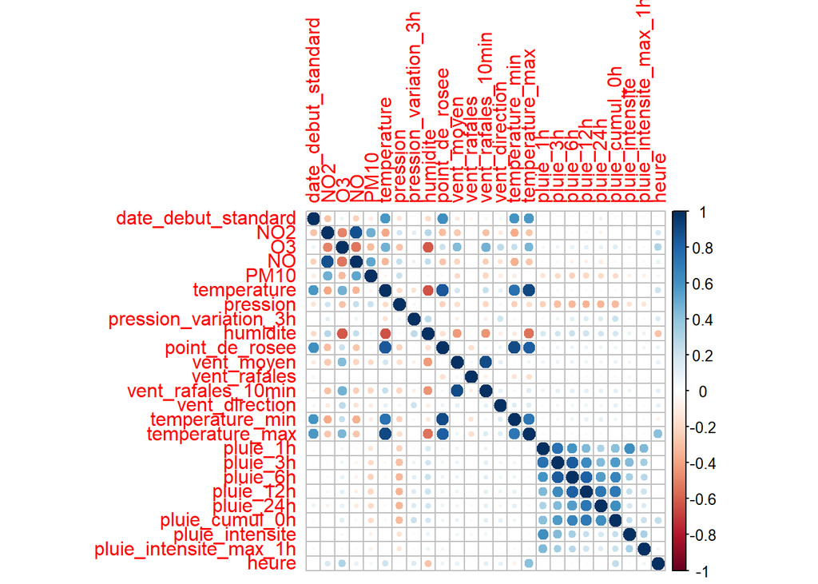

```r
quantitative_vars <- df[, sapply(df, is.numeric)]  # Sélection des variables quantitatives
cor_matrix <- cor(quantitative_vars, use = "complete.obs")
corrplot(cor_matrix, method = "circle")  # Afficher la matrice de corrélation
```

La matrice de corrélation révèle des relations intéressantes entre les variables étudiées. Les variables vent_rafales et vent_direction présentent des corrélations très faibles avec les autres, suggérant leur relative indépendance. Les précipitations, lorsqu’elles sont mesurées par heure, sont positivement corrélées entre elles, reflétant la continuité des période de pluie. La température est fortement corrélée positivement avec les températures maximales et minimales, relation plutôt cohérente, ainsi qu’avec le point de rosée. D’un autre côté, elle montre une corrélation négative marquée avec l’humidité. De même, le point de rosée est étroitement corrélé positivement aux températures maximales et minimales. Concernant le vent, le vent rafales sur 10 minutes est fortement corrélé au vent moyen, indiquant une cohérence dans les variations du vent. Du côté des gaz, le taux d’O3 est corrélé négativement avec l’humidité, ainsi qu’au taux de NO et NO3. Enfin, la date de début est positivement corrélée avec la température et le point de rosée, ce qui pourrait refléter une tendance temporelle ou saisonnière. En dehors de ces observations, les autres variables montrent des corrélations faibles, signalant une faible interdépendance.

**Q.2.2 En se focalisant sur le polluant Ozone (O3), identifier quelques variables statistiquement liées à l’ozone et tracer des graphiques pertinents pour visualiser ce lien.**

Les variables qui semblent les plus liées à l’ozone sont la température, l’humidité et les oxydes d’azotes NO et NO2. Ces variables influencent potentiellement les concentrations d’ozone en raison des conditions météorologiques et des interactions chimiques .

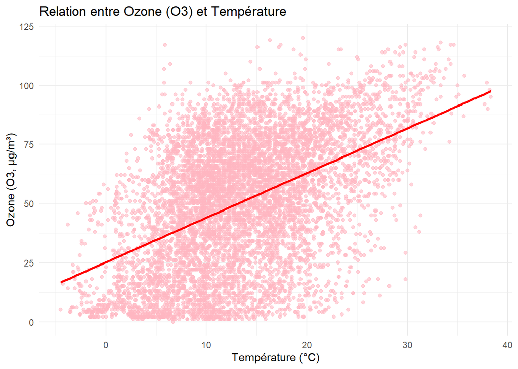

```r
# Graphique 1 : Ozone et température
ggplot(df, aes(x = temperature, y = O3)) +
  geom_point(alpha = 0.6, color = "lightpink") +
  geom_smooth(method = "lm", color = "red", se = FALSE) +
  labs(title = "Relation entre Ozone (O3) et Température",
       x = "Température (°C)", y = "Ozone (O3, µg/m³)") +
  theme_minimal()
```

Bien que le nuage de points soit assez étalé, on constate une certaine tendance liant la température au taux d’ozone comme nous avions pu le remarquer avec le tableau de corrélation.

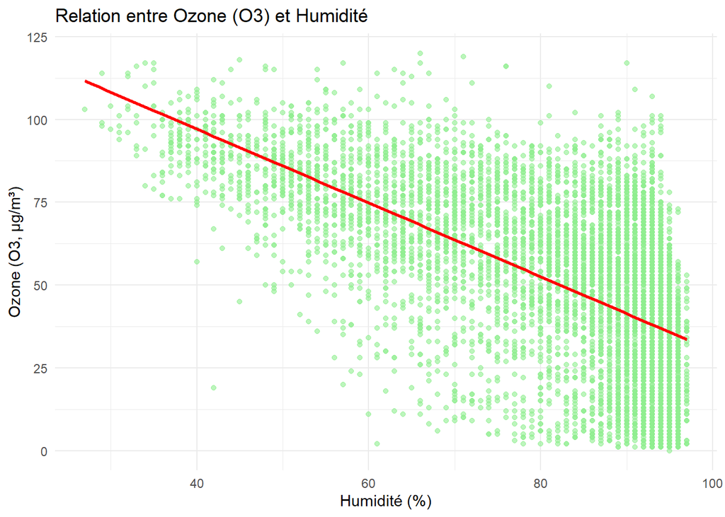

```r
# Graphique 2 : Ozone et Humidité
ggplot(df, aes(x = humidite, y = O3)) +
  geom_point(alpha = 0.6, color = "lightgreen") +
  geom_smooth(method = "lm", color = "red", se = FALSE) +
  labs(title = "Relation entre Ozone (O3) et Humidité",
       x = "Humidité (%)", y = "Ozone (O3, µg/m³)") +
  theme_minimal()
```

De la même manière, nous pouvons voir que le nuage de point semble plutôt linéaires même si les points sont très éparses. Nous remarquons que l’ozone est influencé par certaines conditions météorologiques.

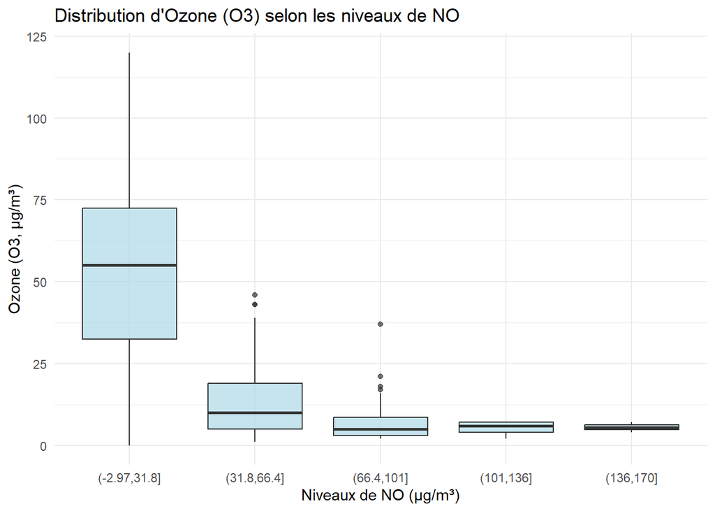

```r
ggplot(df, aes(x = cut(NO, breaks = 5), y = O3)) +
  geom_boxplot(fill = "lightblue", alpha = 0.7) +
  labs(title = "Distribution d'Ozone (O3) selon les niveaux de NO",
       x = "Niveaux de NO (µg/m³)", y = "Ozone (O3, µg/m³)") +
  theme_minimal()
```

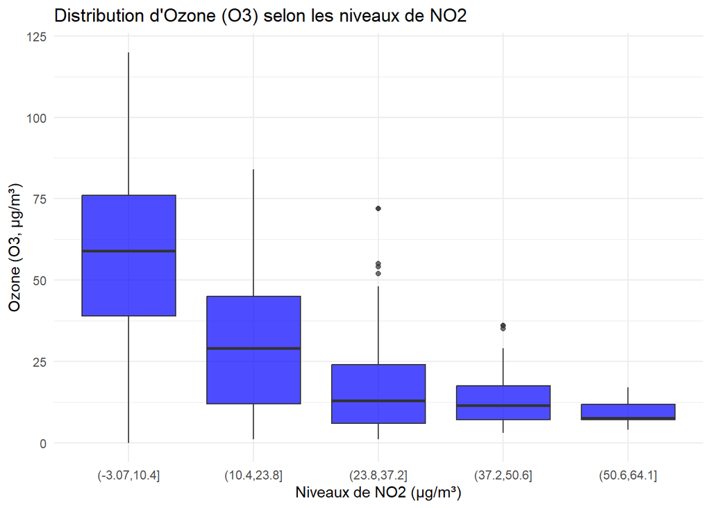

```r
ggplot(df, aes(x = cut(NO2, breaks = 5), y = O3)) +
  geom_boxplot(fill = "blue", alpha = 0.7) +
  labs(title = "Distribution d'Ozone (O3) selon les niveaux de NO2",
       x = "Niveaux de NO2 (µg/m³)", y = "Ozone (O3, µg/m³)") +
  theme_minimal()
```

Ces diagrammes en boîtes à moustaches montrent clairement une relation entre le taux d’O3 et les taux de NO et NO2, confirmant le lien que nous avions pu observer dans le tableau de corrélation. Cette relation doit être liée à des processus atmosphériques. On constate d’ailleurs que les deux graphiques sont assez similaires.

**Q.2.3 Calculer les boites à moustaches parallèles de la variable Ozone, en fonction de l’heure de la journée. Commenter. Reprendre en fonction du jour de la semaine. Commenter.**

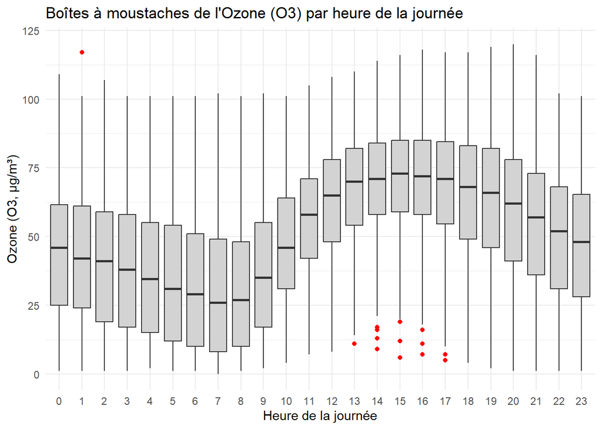

```r
# 2.3 Boîtes à moustaches d'Ozone en fonction de l'heure et du jour
# En fonction de l'heure
ggplot(df, aes(x = factor(heure), y = O3)) +
  geom_boxplot(fill = "lightgrey", outlier.color = "red") +
  labs(title = "Boîtes à moustaches de l'Ozone (O3) par heure de la journée",
       x = "Heure de la journée", y = "Ozone (O3, µg/m³)") +
  theme_minimal()
```

Les concentrations d’ozone (O₃) varient au cours de la journée en suivant un cycle bien marqué lié à la lumière du soleil et aux activités humaines. Comme le montre le graphique en boîte à moustache, les niveaux d’ozone diminuent lentement entre 16h et 8h du matin, car la nuit, il y a moins de lumière et moins d’activités qui produisent de l’ozone. Ensuite, à partir de 8h, les concentrations augmentent rapidement pour atteindre un pic dans l’après-midi, entre 15h et 16h. Cette hausse est due à la lumière du soleil plus intense qui favorise la formation d’ozone, ainsi qu’à l’intensité des activités humaines durant la journée. Les données montrent peu de valeurs aberrantes, ce qui confirme la régularité de ce cycle. Cela met en évidence comment la lumière et les activités humaines influencent directement les variations des niveaux d’ozone au fil de la journée.De plus, nous avions vu que la température était corrélée au taux d’O3 et il fait généralement plus chaud dans la journée avant que la température ne redescende dans l’après midi, nos observations semblent cohérente.

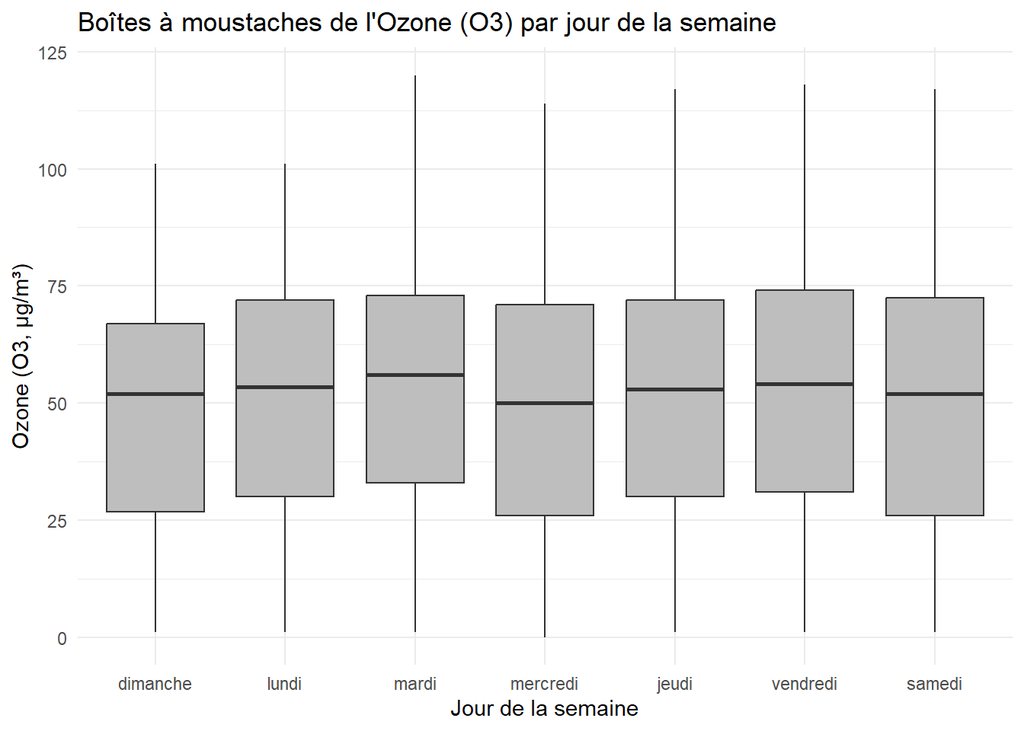

```r
# 2.3 Boîtes à moustaches d'Ozone en fonction du jour
# En fonction du jour
ggplot(df, aes(x = factor(jour), y = O3)) +
  geom_boxplot(fill = "grey", outlier.color = "red") +
  labs(title = "Boîtes à moustaches de l'Ozone (O3) par jour de la semaine",
       x = "Jour de la semaine", y = "Ozone (O3, µg/m³)") +
  theme_minimal()
```

En revanche, on constate que pour les jours, il y a peu de différence. Les taux du dimanche semblent légèrement moins élevés avec des pics moins importants (comme pour le lundi) mais nous ne remarquons pas de différence frappante entre les jours. Les résultat obtenu sont assez homogènes.

**Q2.4 Faire l’Analyse en Composantes Principales du jeu de données complet**

```r
pca.atmo <- PCA(df[c(3:25)], scale.unit = TRUE,graph=FALSE)
pca.atmo$eig
```

```
##          eigenvalue percentage of variance cumulative percentage of variance
## comp 1  5.237946864            22.77368202                          22.77368
## comp 2  4.518372028            19.64509577                          42.41878
## comp 3  2.428103530            10.55697187                          52.97575
## comp 4  1.624593669             7.06345073                          60.03920
## comp 5  1.419210594             6.17048084                          66.20968
## comp 6  1.232341729             5.35800752                          71.56769
## comp 7  1.023319208             4.44921395                          76.01690
## comp 8  0.801136409             3.48320178                          79.50010
## comp 9  0.738888216             3.21255746                          82.71266
## comp 10 0.670623575             2.91575467                          85.62842
## comp 11 0.663475404             2.88467567                          88.51309
## comp 12 0.561345987             2.44063473                          90.95373
## comp 13 0.506390570             2.20169813                          93.15543
## comp 14 0.352689807             1.53343394                          94.68886
## comp 15 0.286229301             1.24447522                          95.93333
## comp 16 0.251944120             1.09540922                          97.02874
## comp 17 0.180951416             0.78674529                          97.81549
## comp 18 0.133747862             0.58151244                          98.39700
## comp 19 0.108395268             0.47128377                          98.86829
## comp 20 0.093451762             0.40631201                          99.27460
## comp 21 0.092183723             0.40079879                          99.67540
## comp 22 0.065141752             0.28322501                          99.95862
## comp 23 0.009517207             0.04137916                         100.00000
```

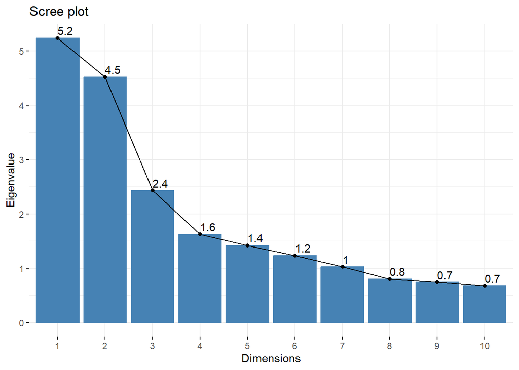

```r
fviz_eig(pca.atmo, choice = "eigenvalue", addlabels=TRUE)
```

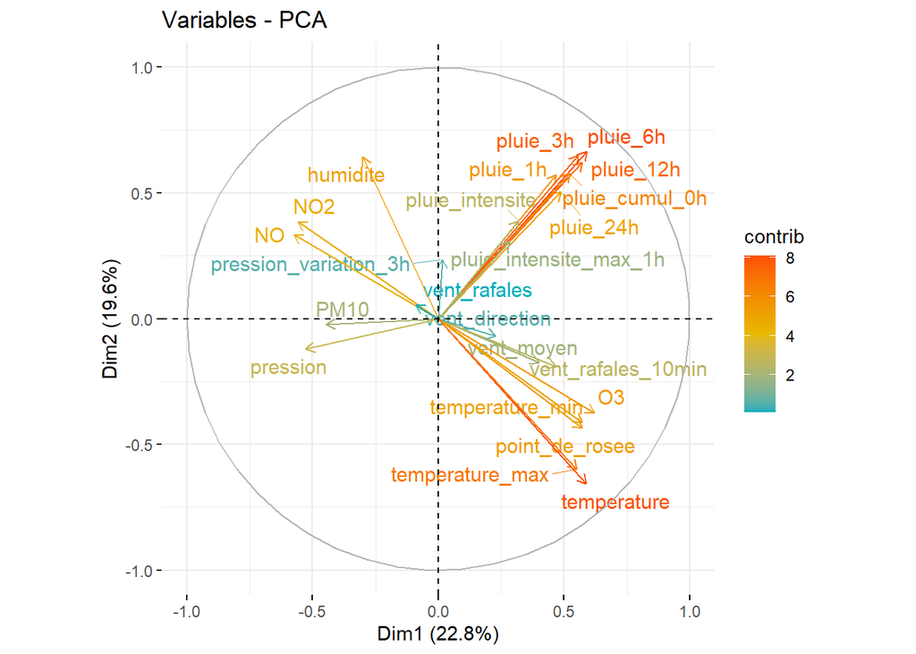

```r
fviz_pca_var(pca.atmo, col.var = "contrib",
             gradient.cols = c("#00AFBB", "#E7B800", "#FC4E07"),
             repel = TRUE)
```

```r
pca.atmo$var$contrib
```

```
##                              Dim.1      Dim.2        Dim.3        Dim.4
## NO2                    5.918444934 3.29200112  2.802240512 1.537815e+01
## O3                     7.380987567 3.11565560  5.333972730 1.635541e-02
## NO                     6.302089102 2.46066875  2.637566771 1.872682e+01
## PM10                   3.788054114 0.01257692  4.720248221 1.665209e+01
## temperature            6.633994423 9.54695303  4.547330658 2.856730e+00
## pression               5.301064681 0.32268042  0.013169986 4.147337e-02
## pression_variation_3h  0.005638858 1.22651182  1.089294286 2.665929e+00
## humidite               1.719780316 9.15297156  3.798662425 8.394408e+00
## point_de_rosee         6.233634513 4.19904821 16.256615561 8.035601e-02
## vent_moyen             3.058818349 0.68089439 18.837491292 7.683151e+00
## vent_rafales           0.148955899 0.06473712  1.271362229 4.078209e-07
## vent_rafales_10min     4.186784865 0.81197843 15.954177172 7.772530e+00
## vent_direction         0.996916960 0.10539260  0.130857712 7.703307e-01
## temperature_min        6.243344511 3.77318787 13.563338113 5.399240e-01
## temperature_max        5.797547212 7.92821733  8.081663288 2.556789e+00
## pluie_1h               4.196470927 7.23765096  0.091313153 4.201000e+00
## pluie_3h               5.921821701 9.29305533  0.112971337 1.199785e+00
## pluie_6h               6.650005339 9.76767173  0.140861341 5.731371e-02
## pluie_12h              6.273210642 8.56039661  0.152642368 3.838721e-01
## pluie_24h              4.550087916 5.63382693  0.075274137 1.705654e+00
## pluie_cumul_0h         5.208243883 7.37672520  0.115761698 3.785645e-02
## pluie_intensite        1.941542573 3.35896204  0.004025662 5.490504e+00
## pluie_intensite_max_1h 1.542560715 2.07823603  0.269159349 2.788982e+00
##                               Dim.5
## NO2                    4.838456e+00
## O3                     2.865439e-01
## NO                     4.655724e+00
## PM10                   2.441316e+00
## temperature            5.336229e-07
## pression               3.969572e-03
## pression_variation_3h  8.918196e+00
## humidite               1.750791e-01
## point_de_rosee         6.335944e-03
## vent_moyen             2.732596e+00
## vent_rafales           2.558496e+00
## vent_rafales_10min     3.575330e+00
## vent_direction         3.573381e+00
## temperature_min        2.119895e-02
## temperature_max        3.770125e-01
## pluie_1h               1.188632e+01
## pluie_3h               1.395795e+00
## pluie_6h               5.310173e-01
## pluie_12h              6.017459e+00
## pluie_24h              8.581536e+00
## pluie_cumul_0h         7.085974e+00
## pluie_intensite        1.728755e+01
## pluie_intensite_max_1h 1.305071e+01
```

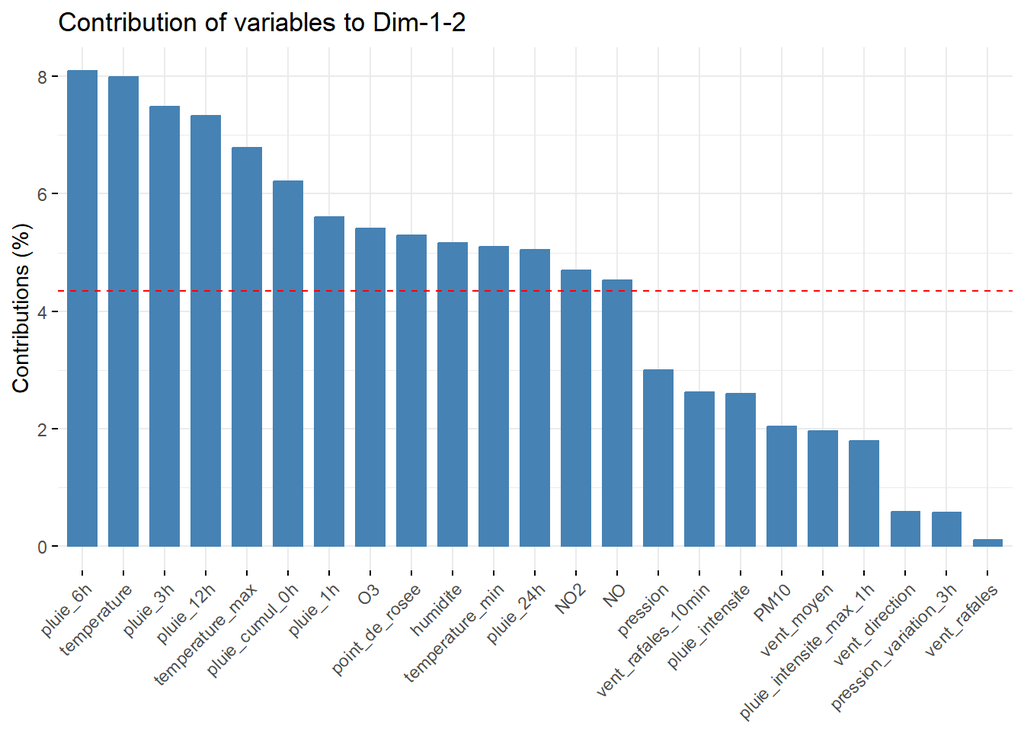

```r
fviz_contrib(pca.atmo,choice="var",axes = c(1,2))
```

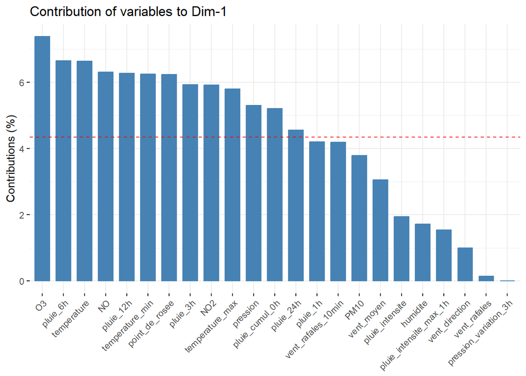

```r
fviz_contrib(pca.atmo,choice="var",axes = 1)
```

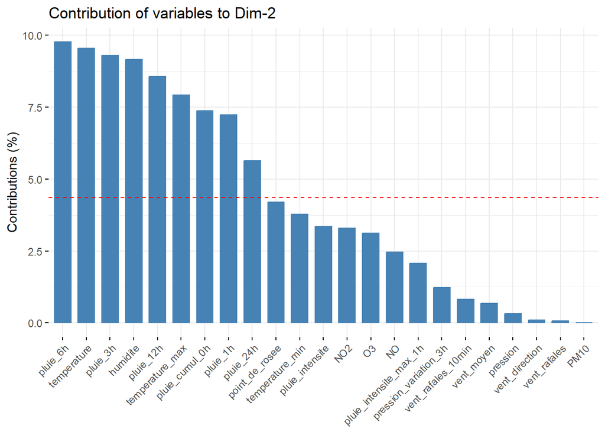

```r
fviz_contrib(pca.atmo,choice="var",axes = 2)
```

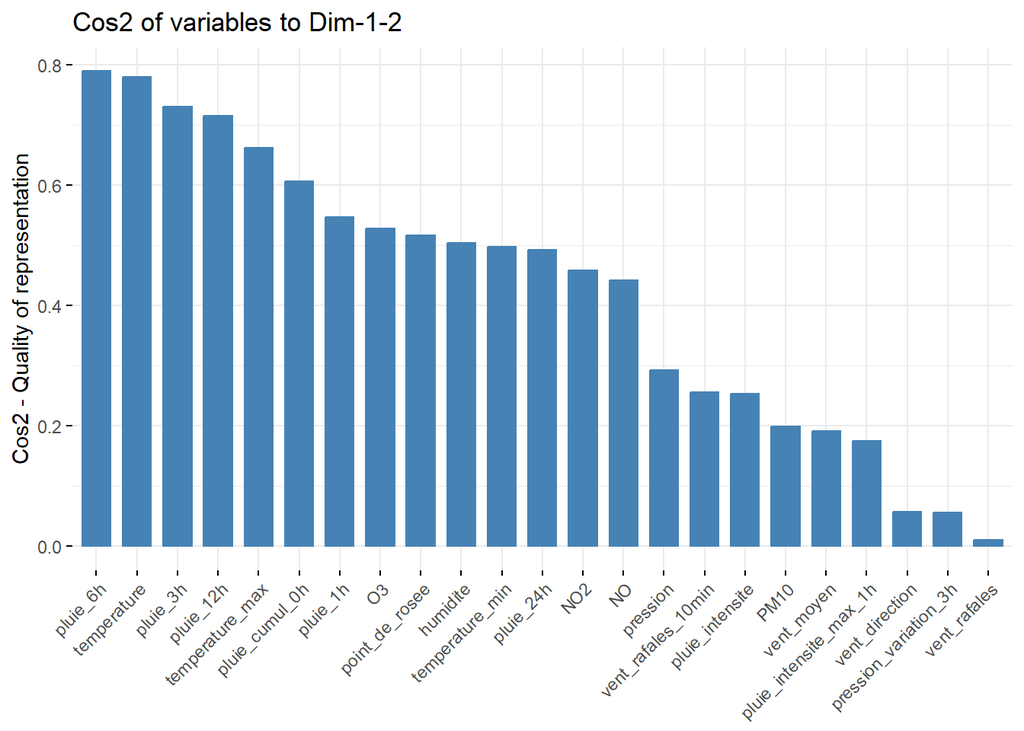

```r
fviz_cos2(pca.atmo, choice="var", axes = c(1,2))
```

```r
var <- get_pca_var(pca.atmo)
var
```

```
## Principal Component Analysis Results for variables
##  ===================================================
##   Name       Description
## 1 "$coord"   "Coordinates for the variables"
## 2 "$cor"     "Correlations between variables and dimensions"
## 3 "$cos2"    "Cos2 for the variables"
## 4 "$contrib" "contributions of the variables"
```

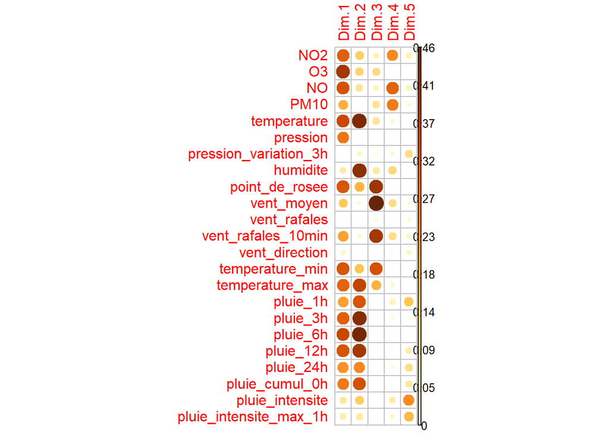

```r
corrplot(var$cos2, is.corr=FALSE)
```

L’Analyse en Composantes Principales (ACP) réalisée met en évidence plusieurs dimensions expliquant la variabilité des données initiales. D’après le tableau, conformément au critère de Kaiser, on ne retient que les sept premières dimensions (car ils présentent des valeurs propres supérieures à 1). Ces dimensions cumulent environ 76% de la variance totale, ce qui est satisfaisant pour interpréter les données. Parmi elles, les deux premières dimensions expliquent un peu plus de 42% de la variance, justifiant l’utilisation du plan factoriel 1-2 pour une analyse approfondie. Les dimensions 3 à 7 apportent des informations complémentaires, mais leur contribution est moins significative, avec des pourcentages entre 5 et 10%. Les dimensions restantes n’ajoutent qu’une part négligeable de variance.

L’analyse des pourcentages cumulés montre que les deux premières dimensions capturent la majorité de l’information pertinente. La dimension 1, qui explique 22.8% de la variance, semble être liée principalement aux variables représentant les polluants atmosphériques (O3, NO) ainsi qu’à des variables climatiques comme la température, la pluie et le point de rosée. La dimension 2, quant à elle, explique 19.64% de la variance et est fortement influencée par des facteurs liés à l’humidité et à certaines variables pluviométriques (pluie_6h, pluie_3h). Les dimensions suivantes (3, 4, etc.) permettent de capturer des aspects plus spécifiques des données, tels que les effets des vents et des phénomènes climatiques ponctuels.

Plus précisément, les contributions des variables offrent un aperçu de leur importance dans la construction des dimensions. Pour la dimension 1, les variables les plus contributives sont O3 (7.38%), NO (6.30%), pluie_6h (6.65%), et temperature (6.63%). Cela indique que cette dimension reflète principalement les niveaux de pollution atmosphérique et leurs interactions avec des variables climatiques impportantes. Sur la dimension 2, les principales contributions proviennent de humidite (9.15%), temperature (9.55%), pluie_6h (9.77%) et pluie_3h (9.29%) , suggérant une relation entre ces variables et les conditions météorologiques générales.

Des variables spécifiques dominent les dimensions suivantes. Par exemple, sur la dimension 3, point_de_rosee (16.25%), vent_moyen (18.83%) et vent_rafales_10min (15.95%) expliquent à eux seuls plus de 51% de la dimension, indiquant que cette dimension est fortement influencée par des conditions de vent et des variations de rosée. Enfin, la dimension 4 est marquée par des contributions élevées de NO (18.72%) et PM10 (16.65%), traduisant des relations entre la pollution atmosphérique et des phénomènes ponctuels comme des rafales de vent.

Le graphique des variables dans le plan factoriel 1-2 révèle les regroupements naturels entre elles. Les variables liées aux polluants, comme NO et NO2 apparaissent proches et opposés à O3 traduisant une corrélation fortement négative entre ces éléments. Indiquant qu’un niveau élevé de l’un impliquera un niveau faible de l’autre. De leur côté, les variables météorologiques de temperature et de pluie forment deux autres groupes, montrant que les variables sont fortement liées dans chacun des groupes. En revanche, les deux groupes semblent plutôt décorrélés car perpendiculaires. Les variables associées au vent, comme vent_moyen ou vent_rafales, sont susceptibles de se distinguer des autres groupes en raison de leur influence sur des phénomènes spécifiques. En revanche, ils sont assez mal projetés cintrairement aux variables de pluie par heure et de température.

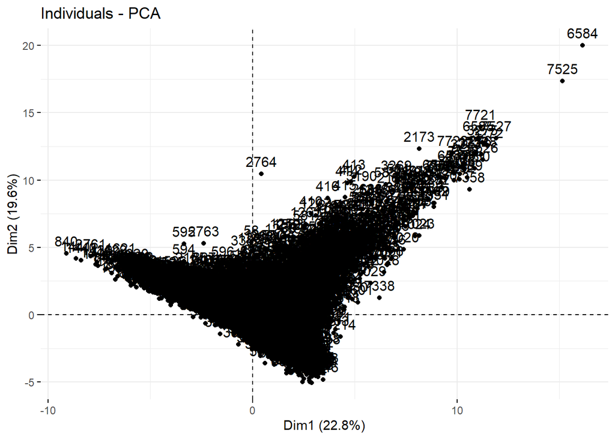

```r
fviz_pca_ind(pca.atmo,axes = c(1,2) )
```

```r
#fviz_contrib(pca.atmo,choice="ind",axes = 1)  #le rendu est illisible car trop d'individus
#fviz_contrib(pca.atmo,choice="ind",axes = c(1,2))
```

Les individus ayant des coordonnées extrêmes sur les dimensions principales méritent une attention particulière. Par exemple, ceux ayant des abscisses supérieures à 3 sur la dimension 1 peuvent représenter des moments de pollution (corrélés à des niveaux élevés de O3 ou NO), de températures ou de pluie particuliers, l’effet des températures élevées et sèches sur les concentrations d’ozone. De même, les individus avec des ordonnées supérieures à 3 sur la dimension 2 pourraient refléter des moments caractérisés par une humidité élevée ou des précipitations importantes, montrant l’influence des précipitations et des vents sur la dispersion et le nettoyage des polluants atmosphériques. Les observations 6584 et 7525 devait être des jours de pluie particulièrement intenses par exemple, puisqu’il a à la fois une abscisse est une ordonnée vraiment grande et est très excentré du nuage de point au vu de leur emplacement et de ce que nous avons pu analyser de l’ACP.

En conclusion, cette ACP met en évidence les relations complexes entre les variables climatiques et les polluants atmosphériques. Les premières dimensions capturent efficacement la variabilité principale, tandis que les suivantes apportent des informations spécifiques sur des phénomènes ponctuels. Les regroupements de variables suggèrent des corrélations naturelles dans les données, et l’analyse des individus spécifiques offre des pistes pour comprendre les moments singuliers. Ces résultats peuvent être utilisés pour identifier des patterns saisonniers, détecter des anomalies, ou formuler des hypothèses sur les interactions entre la pollution et les conditions météorologiques.

**Q.2.5 Reprendre l’ACP complète en incluant une seule variable de pluie. Comparer**

```r
# Sélection d'une seule variable de pluie (exemple : pluie_1h)
selected_data <- df[c(3:25)]  # Sélection des colonnes initiales pour l'ACP complète
selected_data <- selected_data[, !names(selected_data) %in% c("pluie_3h", "pluie_6h", "pluie_12h", "pluie_24h", "pluie_cumul_0h", "pluie_intensite", "pluie_intensite_max_1h")] # Ajout uniquement de pluie_1h

pca_with_single_pluie <- PCA(selected_data, scale.unit = TRUE, graph = FALSE)

# Comparaison des valeurs propres
print("Valeurs propres ACP complète avec toutes les variables de pluie :")
```

```
## [1] "Valeurs propres ACP complète avec toutes les variables de pluie :"
```

```r
print(pca.atmo$eig)
```

```
##          eigenvalue percentage of variance cumulative percentage of variance
## comp 1  5.237946864            22.77368202                          22.77368
## comp 2  4.518372028            19.64509577                          42.41878
## comp 3  2.428103530            10.55697187                          52.97575
## comp 4  1.624593669             7.06345073                          60.03920
## comp 5  1.419210594             6.17048084                          66.20968
## comp 6  1.232341729             5.35800752                          71.56769
## comp 7  1.023319208             4.44921395                          76.01690
## comp 8  0.801136409             3.48320178                          79.50010
## comp 9  0.738888216             3.21255746                          82.71266
## comp 10 0.670623575             2.91575467                          85.62842
## comp 11 0.663475404             2.88467567                          88.51309
## comp 12 0.561345987             2.44063473                          90.95373
## comp 13 0.506390570             2.20169813                          93.15543
## comp 14 0.352689807             1.53343394                          94.68886
## comp 15 0.286229301             1.24447522                          95.93333
## comp 16 0.251944120             1.09540922                          97.02874
## comp 17 0.180951416             0.78674529                          97.81549
## comp 18 0.133747862             0.58151244                          98.39700
## comp 19 0.108395268             0.47128377                          98.86829
## comp 20 0.093451762             0.40631201                          99.27460
## comp 21 0.092183723             0.40079879                          99.67540
## comp 22 0.065141752             0.28322501                          99.95862
## comp 23 0.009517207             0.04137916                         100.00000
```

```r
print("Valeurs propres ACP avec une seule variable de pluie :")
```

```
## [1] "Valeurs propres ACP avec une seule variable de pluie :"
```

```r
print(pca_with_single_pluie$eig)
```

```
##          eigenvalue percentage of variance cumulative percentage of variance
## comp 1  4.949596136            30.93497585                          30.93498
## comp 2  2.458619242            15.36637027                          46.30135
## comp 3  1.718584114            10.74115072                          57.04250
## comp 4  1.281970882             8.01231801                          65.05481
## comp 5  1.247408006             7.79630004                          72.85111
## comp 6  1.029613284             6.43508303                          79.28620
## comp 7  0.773383629             4.83364768                          84.11985
## comp 8  0.702849889             4.39281181                          88.51266
## comp 9  0.650342632             4.06464145                          92.57730
## comp 10 0.514416769             3.21510480                          95.79240
## comp 11 0.257797152             1.61123220                          97.40364
## comp 12 0.137197600             0.85748500                          98.26112
## comp 13 0.109064113             0.68165070                          98.94277
## comp 14 0.093920177             0.58700111                          99.52977
## comp 15 0.065657340             0.41035838                          99.94013
## comp 16 0.009579034             0.05986896                         100.00000
```

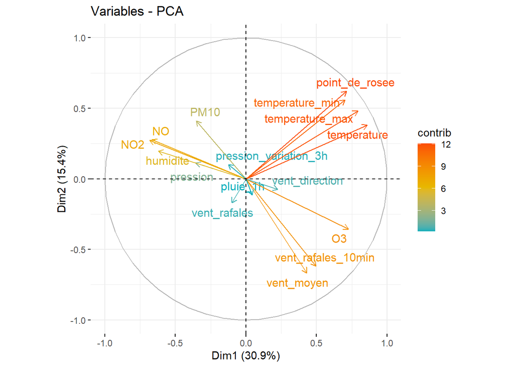

```r
# Visualisation des contributions des variables pour les deux ACP
fviz_pca_var(pca_with_single_pluie, col.var = "contrib",
             gradient.cols = c("#00AFBB", "#E7B800", "#FC4E07"),
             repel = TRUE)
```

```r
# Comparaison des contributions des variables entre les deux ACP
print("Contributions des variables - ACP complète :")
```

```
## [1] "Contributions des variables - ACP complète :"
```

```r
print(pca.atmo$var$contrib)
```

```
##                              Dim.1      Dim.2        Dim.3        Dim.4
## NO2                    5.918444934 3.29200112  2.802240512 1.537815e+01
## O3                     7.380987567 3.11565560  5.333972730 1.635541e-02
## NO                     6.302089102 2.46066875  2.637566771 1.872682e+01
## PM10                   3.788054114 0.01257692  4.720248221 1.665209e+01
## temperature            6.633994423 9.54695303  4.547330658 2.856730e+00
## pression               5.301064681 0.32268042  0.013169986 4.147337e-02
## pression_variation_3h  0.005638858 1.22651182  1.089294286 2.665929e+00
## humidite               1.719780316 9.15297156  3.798662425 8.394408e+00
## point_de_rosee         6.233634513 4.19904821 16.256615561 8.035601e-02
## vent_moyen             3.058818349 0.68089439 18.837491292 7.683151e+00
## vent_rafales           0.148955899 0.06473712  1.271362229 4.078209e-07
## vent_rafales_10min     4.186784865 0.81197843 15.954177172 7.772530e+00
## vent_direction         0.996916960 0.10539260  0.130857712 7.703307e-01
## temperature_min        6.243344511 3.77318787 13.563338113 5.399240e-01
## temperature_max        5.797547212 7.92821733  8.081663288 2.556789e+00
## pluie_1h               4.196470927 7.23765096  0.091313153 4.201000e+00
## pluie_3h               5.921821701 9.29305533  0.112971337 1.199785e+00
## pluie_6h               6.650005339 9.76767173  0.140861341 5.731371e-02
## pluie_12h              6.273210642 8.56039661  0.152642368 3.838721e-01
## pluie_24h              4.550087916 5.63382693  0.075274137 1.705654e+00
## pluie_cumul_0h         5.208243883 7.37672520  0.115761698 3.785645e-02
## pluie_intensite        1.941542573 3.35896204  0.004025662 5.490504e+00
## pluie_intensite_max_1h 1.542560715 2.07823603  0.269159349 2.788982e+00
##                               Dim.5
## NO2                    4.838456e+00
## O3                     2.865439e-01
## NO                     4.655724e+00
## PM10                   2.441316e+00
## temperature            5.336229e-07
## pression               3.969572e-03
## pression_variation_3h  8.918196e+00
## humidite               1.750791e-01
## point_de_rosee         6.335944e-03
## vent_moyen             2.732596e+00
## vent_rafales           2.558496e+00
## vent_rafales_10min     3.575330e+00
## vent_direction         3.573381e+00
## temperature_min        2.119895e-02
## temperature_max        3.770125e-01
## pluie_1h               1.188632e+01
## pluie_3h               1.395795e+00
## pluie_6h               5.310173e-01
## pluie_12h              6.017459e+00
## pluie_24h              8.581536e+00
## pluie_cumul_0h         7.085974e+00
## pluie_intensite        1.728755e+01
## pluie_intensite_max_1h 1.305071e+01
```

```r
print("Contributions des variables - ACP avec une seule variable de pluie :")
```

```
## [1] "Contributions des variables - ACP avec une seule variable de pluie :"
```

```r
print(pca_with_single_pluie$var$contrib)
```

```
##                             Dim.1      Dim.2        Dim.3       Dim.4
## NO2                    9.40602718  2.9916764 1.003862e+01 10.27636759
## O3                    10.63230500  5.1213947 2.179962e-01  0.02085763
## NO                     8.96301960  3.1268509 1.386157e+01  8.76187947
## PM10                   2.50496533  6.8611846 1.874945e+01  0.99857592
## temperature           14.90654593  5.9205883 3.270999e+00  0.10783941
## pression               2.56362091  0.5096020 4.277206e+00  6.96300212
## pression_variation_3h  0.31557610  0.4308076 4.752845e+00 19.41905380
## humidite               7.80106906  1.5921935 1.898976e+01  2.99361920
## point_de_rosee        10.26833478 15.7596561 2.369482e-01  1.07669579
## vent_moyen             3.76483824 18.0627030 7.077883e+00  6.42488541
## vent_rafales           0.20707304  1.1720667 1.837492e-04  2.02988448
## vent_rafales_10min     4.95339571 15.5284491 6.698808e+00  7.67408942
## vent_direction         1.03475600  0.2247925 7.098260e-01  7.42963091
## temperature_min        9.94003190 12.7164379 1.865785e+00  1.03812505
## temperature_max       12.69853483  9.4482360 2.346739e+00  0.35582145
## pluie_1h               0.03990639  0.5333606 6.905369e+00 24.42967234
##                             Dim.5
## NO2                    0.19221438
## O3                     1.99490007
## NO                     0.50887881
## PM10                   0.03002751
## temperature            0.11003936
## pression              21.78305139
## pression_variation_3h 24.04319140
## humidite               0.80545828
## point_de_rosee         0.80855506
## vent_moyen             0.23919097
## vent_rafales           0.02961404
## vent_rafales_10min     0.52941189
## vent_direction        37.44472911
## temperature_min        0.06209666
## temperature_max        0.15455790
## pluie_1h              11.26408320
```

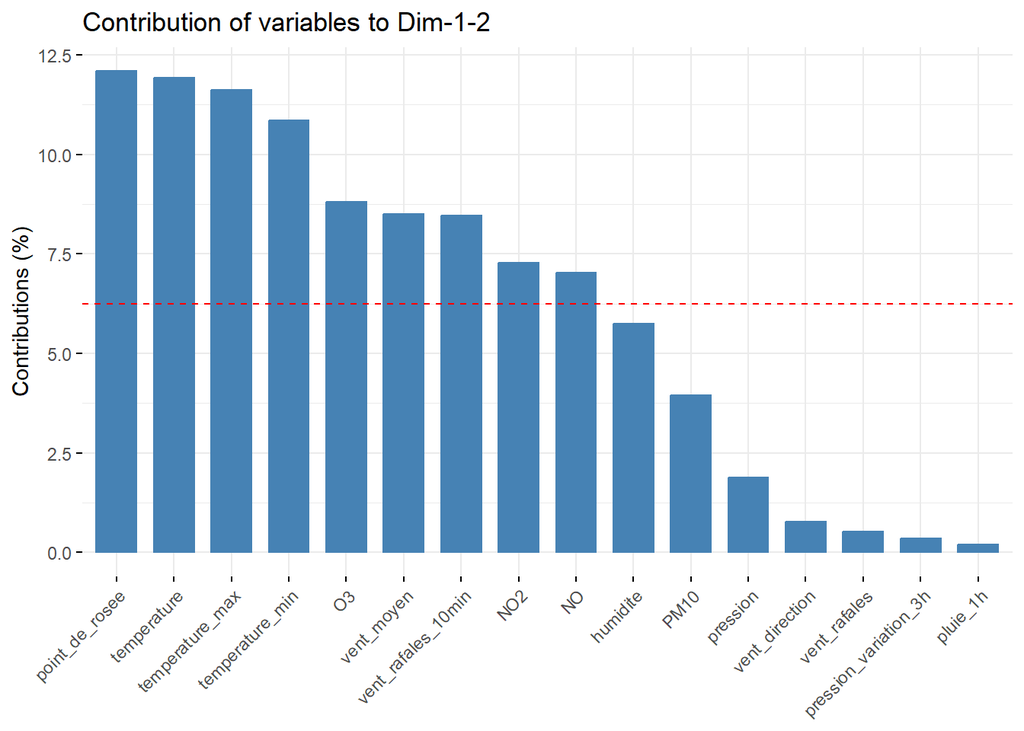

```r
fviz_contrib(pca_with_single_pluie,choice="var",axes = c(1,2))
```

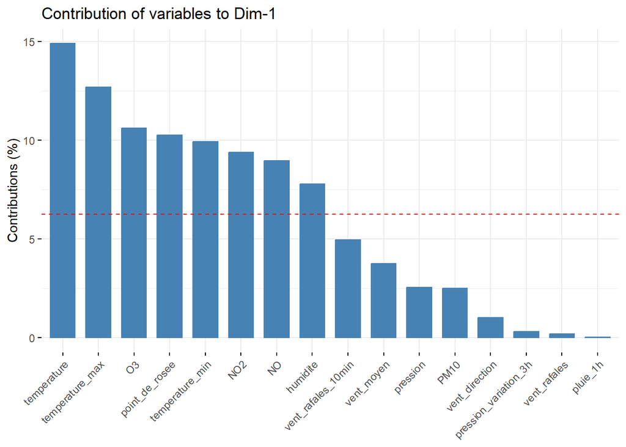

```r
fviz_contrib(pca_with_single_pluie,choice="var",axes = 1)
```

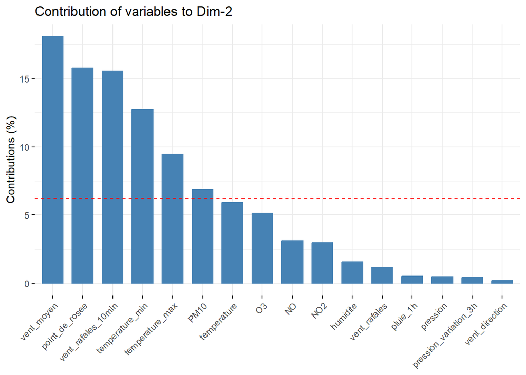

```r
fviz_contrib(pca_with_single_pluie,choice="var",axes = 2)
```

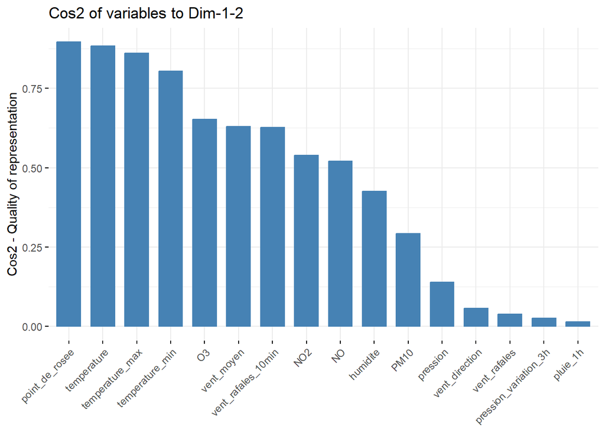

```r
fviz_cos2(pca_with_single_pluie, choice="var", axes = c(1,2))
```

En comparant les valeurs propres après avoir conservé uniquement la variable pluie_1h, on observe que la dimension 1 dans l’ACP avec une seule variable de pluie explique presque 31% de la variance, contre 22.8% dans l’ACP complète. Cela signifie que l’ajout d’une seule variable de pluie, tout en retirant les autres variables de précipitation, concentre davantage l’information sur la première dimension. D’un autre côté, la dimension 2 de cette nouvelle ACP explique 15.37%, contre 19.64% dans l’ACP initiale. En conséquence, la somme des inerties expliquées par les deux premières dimensions est assez proche entre les deux analyses (46.30% contre 42.42%), bien que la distribution soit différente. Ces résultats montrent que les variables de pluie supplémentaires dans l’ACP complète dispersaient l’information à travers plusieurs dimensions. En réduisant les variables de pluie à une seule, leur influence est concentrée, augmentant ainsi l’importance relative des autres variables (comme la pollution ou la température). De plus, avec le critère de Kaiser, nous conservons les 6 premières dimensions alors que nous n’en conservions 7 avant.

La répartition des contributions des variables change significativement entre les deux ACP. Dans l’ACP complète : - La dimension 1 est influencée par O3 (7.38%), NO (6.30%), pluie_6h (6.65%), et temperature (6.63%). - La dimension 2 est marquée par temperature (9.55%), humidite (9.15%), et pluie_6h (9.77%) et pluie_3h (9.29%). Dans l’ACP avec une seule variable de pluie : - La dimension 1 voit une augmentation notable de la contribution de temperature (14.91%), temperature_max (12.70%) suivi de O3 (10.63%), et point_de_rosee (10.27%). - La dimension 2 est influencée par vent_moyen (18.06%), point_de_rosee (15.76%) et vent_rafales_10min (15.53%). Cela indique que la suppression des variables de pluie supplémentaires redistribue l’influence des variables climatiques (comme le vent et le point de rosée) et des polluants sur les dimensions principales. Dans l’ACP initiale, les variables de pluie jouaient un rôle plus important, mais en réduisant leur nombre, d’autres variables prennent le relais.

Les différences dans les contributions des variables affectent l’interprétation des dimensions principales : - Dans l’ACP complète, la dimension 1 est un mélange d’effets de la pollution (O3, NO), des précipitations et de la température, tandis que la dimension 2 est fortement liée aux variations de température, d’humidité, et de précipitations. - Dans l’ACP avec une seule variable de pluie, la dimension 1 devient davantage centrée sur la température et les polluants comme O3 et NO2. La dimension 2 se concentre sur les effets du vent et du point de rosée, indiquant un glissement vers des phénomènes climatiques plus dynamiques.

La suppression des variables de pluie supplémentaires change également les relations entre variables : - Dans l’ACP complète, les variables de pluie comme pluie_6h, pluie_3h, et pluie_24h avaient des contributions réparties sur plusieurs dimensions, suggérant une interaction complexe avec les autres variables. Dans l’ACP simplifiée, pluie_1h est la seule variable de pluie et contribue principalement à la dimension 4 (24.43%). Cela montre que ses interactions avec les autres variables sont moins dominantes dans les dimensions principales, mais concentrées sur une seule dimension secondaire.Cette réduction des variables de pluie met en lumière les relations entre d’autres variables, comme le vent, la température, et les polluants, qui étaient auparavant masquées par la complexité des interactions pluviales. - On constate également que la projection des données n’est donc pas la même. Alors que les variables de températures se trouvaient dans la même direction que O3, elles se trouvent, dans le cas de l’ACP simplifiée, presque perpendiculaire à O3.

En résumé, l’ACP avec une seule variable de pluie concentre l’information et modifie les relations entre variables, simplifiant l’interprétation des dimensions principales. Cependant, l’ACP complète capture une vue plus détaillée des interactions complexes entre les précipitations et les autres facteurs climatiques et polluants. Le choix entre ces deux approches dépend de l’objectif de l’analyse : une vision simplifiée et ciblée ou une exploration plus détaillée et exhaustive.

**Q.2.6 Reprendre une ACP en en incluant une seule variable par groupe de variables identiques (ie une seule variable de pluie, une seule variable de vent. . . .), les autres pouvant être mises en variables supplémentaires. Comparer.**

```r
# Création des données principales
df_principal <- data.frame(NO = df$NO, O3 = df$O3, PM10 = df$PM10, temperature = df$temperature,
  pression = df$pression, humidite = df$humidite, point_de_rosee = df$point_de_rosee,
  vent_moyen = df$vent_moyen, pluie_1h = df$pluie_1h)

# Création des variables supplémentaires
df_supp <- data.frame(temperature_min = df$temperature_min, temperature_max = df$temperature_max,
  vent_rafales = df$vent_rafales, vent_direction = df$vent_direction, pluie_6h = df$pluie_6h,
  pluie_3h = df$pluie_3h, pluie_24h = df$pluie_24h,NO2 = df$NO2,
  pression_variation_3h = df$pression_variation_3h, vent_rafales_10min = df$vent_rafales_10min,
  pluie_12h = df$pluie_12h, pluie_cumul_0h = df$pluie_cumul_0h, pluie_intensite = df$pluie_intensite,
  pluie_intensite_max_1h = df$pluie_intensite_max_1h)

# Création du dataframe combiné
df_combine <- cbind(df_principal, df_supp)

pca_with_princip <- PCA(df_principal, scale.unit = TRUE, graph = FALSE)

# Comparaison des valeurs propres
print("Valeurs propres ACP complète avec toutes les variables :")
```

```
## [1] "Valeurs propres ACP complète avec toutes les variables :"
```

```r
print(pca.atmo$eig)
```

```
##          eigenvalue percentage of variance cumulative percentage of variance
## comp 1  5.237946864            22.77368202                          22.77368
## comp 2  4.518372028            19.64509577                          42.41878
## comp 3  2.428103530            10.55697187                          52.97575
## comp 4  1.624593669             7.06345073                          60.03920
## comp 5  1.419210594             6.17048084                          66.20968
## comp 6  1.232341729             5.35800752                          71.56769
## comp 7  1.023319208             4.44921395                          76.01690
## comp 8  0.801136409             3.48320178                          79.50010
## comp 9  0.738888216             3.21255746                          82.71266
## comp 10 0.670623575             2.91575467                          85.62842
## comp 11 0.663475404             2.88467567                          88.51309
## comp 12 0.561345987             2.44063473                          90.95373
## comp 13 0.506390570             2.20169813                          93.15543
## comp 14 0.352689807             1.53343394                          94.68886
## comp 15 0.286229301             1.24447522                          95.93333
## comp 16 0.251944120             1.09540922                          97.02874
## comp 17 0.180951416             0.78674529                          97.81549
## comp 18 0.133747862             0.58151244                          98.39700
## comp 19 0.108395268             0.47128377                          98.86829
## comp 20 0.093451762             0.40631201                          99.27460
## comp 21 0.092183723             0.40079879                          99.67540
## comp 22 0.065141752             0.28322501                          99.95862
## comp 23 0.009517207             0.04137916                         100.00000
```

```r
print("Valeurs propres ACP avec variables principales :")
```

```
## [1] "Valeurs propres ACP avec variables principales :"
```

```r
print(pca_with_princip$eig)
```

```
##        eigenvalue percentage of variance cumulative percentage of variance
## comp 1 3.16930948             35.2145498                          35.21455
## comp 2 1.54876001             17.2084446                          52.42299
## comp 3 1.33895403             14.8772670                          67.30026
## comp 4 0.99374980             11.0416645                          78.34193
## comp 5 0.70728166              7.8586851                          86.20061
## comp 6 0.53691887              5.9657652                          92.16638
## comp 7 0.41961352              4.6623725                          96.82875
## comp 8 0.26800318              2.9778131                          99.80656
## comp 9 0.01740946              0.1934384                         100.00000
```

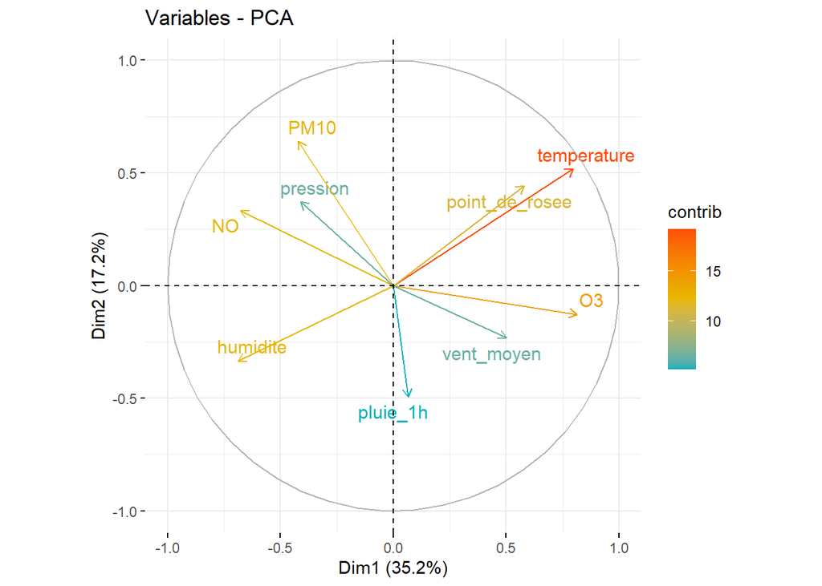

```r
# Visualisation des contributions des variables
fviz_pca_var(pca_with_princip, col.var = "contrib",
             gradient.cols = c("#00AFBB", "#E7B800", "#FC4E07"),
             repel = TRUE)
```

```r
# Comparaison des contributions des variables entre les deux ACP
print("Contributions des variables - ACP complète :")
```

```
## [1] "Contributions des variables - ACP complète :"
```

```r
print(pca.atmo$var$contrib)
```

```
##                              Dim.1      Dim.2        Dim.3        Dim.4
## NO2                    5.918444934 3.29200112  2.802240512 1.537815e+01
## O3                     7.380987567 3.11565560  5.333972730 1.635541e-02
## NO                     6.302089102 2.46066875  2.637566771 1.872682e+01
## PM10                   3.788054114 0.01257692  4.720248221 1.665209e+01
## temperature            6.633994423 9.54695303  4.547330658 2.856730e+00
## pression               5.301064681 0.32268042  0.013169986 4.147337e-02
## pression_variation_3h  0.005638858 1.22651182  1.089294286 2.665929e+00
## humidite               1.719780316 9.15297156  3.798662425 8.394408e+00
## point_de_rosee         6.233634513 4.19904821 16.256615561 8.035601e-02
## vent_moyen             3.058818349 0.68089439 18.837491292 7.683151e+00
## vent_rafales           0.148955899 0.06473712  1.271362229 4.078209e-07
## vent_rafales_10min     4.186784865 0.81197843 15.954177172 7.772530e+00
## vent_direction         0.996916960 0.10539260  0.130857712 7.703307e-01
## temperature_min        6.243344511 3.77318787 13.563338113 5.399240e-01
## temperature_max        5.797547212 7.92821733  8.081663288 2.556789e+00
## pluie_1h               4.196470927 7.23765096  0.091313153 4.201000e+00
## pluie_3h               5.921821701 9.29305533  0.112971337 1.199785e+00
## pluie_6h               6.650005339 9.76767173  0.140861341 5.731371e-02
## pluie_12h              6.273210642 8.56039661  0.152642368 3.838721e-01
## pluie_24h              4.550087916 5.63382693  0.075274137 1.705654e+00
## pluie_cumul_0h         5.208243883 7.37672520  0.115761698 3.785645e-02
## pluie_intensite        1.941542573 3.35896204  0.004025662 5.490504e+00
## pluie_intensite_max_1h 1.542560715 2.07823603  0.269159349 2.788982e+00
##                               Dim.5
## NO2                    4.838456e+00
## O3                     2.865439e-01
## NO                     4.655724e+00
## PM10                   2.441316e+00
## temperature            5.336229e-07
## pression               3.969572e-03
## pression_variation_3h  8.918196e+00
## humidite               1.750791e-01
## point_de_rosee         6.335944e-03
## vent_moyen             2.732596e+00
## vent_rafales           2.558496e+00
## vent_rafales_10min     3.575330e+00
## vent_direction         3.573381e+00
## temperature_min        2.119895e-02
## temperature_max        3.770125e-01
## pluie_1h               1.188632e+01
## pluie_3h               1.395795e+00
## pluie_6h               5.310173e-01
## pluie_12h              6.017459e+00
## pluie_24h              8.581536e+00
## pluie_cumul_0h         7.085974e+00
## pluie_intensite        1.728755e+01
## pluie_intensite_max_1h 1.305071e+01
```

```r
print("Contributions des variables - ACP avec variables principales :")
```

```
## [1] "Contributions des variables - ACP avec variables principales :"
```

```r
print(pca_with_princip$var$contrib)
```

```
##                     Dim.1     Dim.2       Dim.3       Dim.4        Dim.5
## NO             14.4983926  7.169441  0.16687571 21.59128778 3.081725e-01
## O3             20.8947296  1.050258  4.99640024  0.24026630 1.436225e-04
## PM10            5.6037899 26.446067  0.04693921 20.29597132 1.590018e+00
## temperature    20.0861178 17.384811  4.56028276  0.09081557 1.090934e+00
## pression        5.3131420  8.939287 11.57379367 10.60877586 5.848786e+01
## humidite       14.9724315  7.169522 16.89636834  2.43784930 7.927853e-01
## point_de_rosee 10.5852531 12.703686 28.69711607  0.44955562 4.716636e-01
## vent_moyen      7.9079303  3.453768 18.79410693 16.55144839 3.049336e-03
## pluie_1h        0.1382133 15.683160 14.26811707 27.73402987 3.725537e+01
```

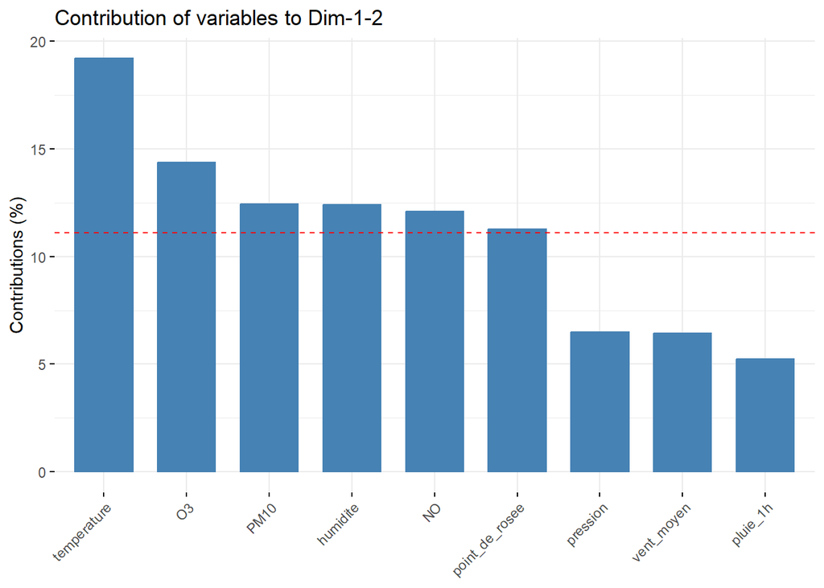

```r
fviz_contrib(pca_with_princip,choice="var",axes = c(1,2))
```

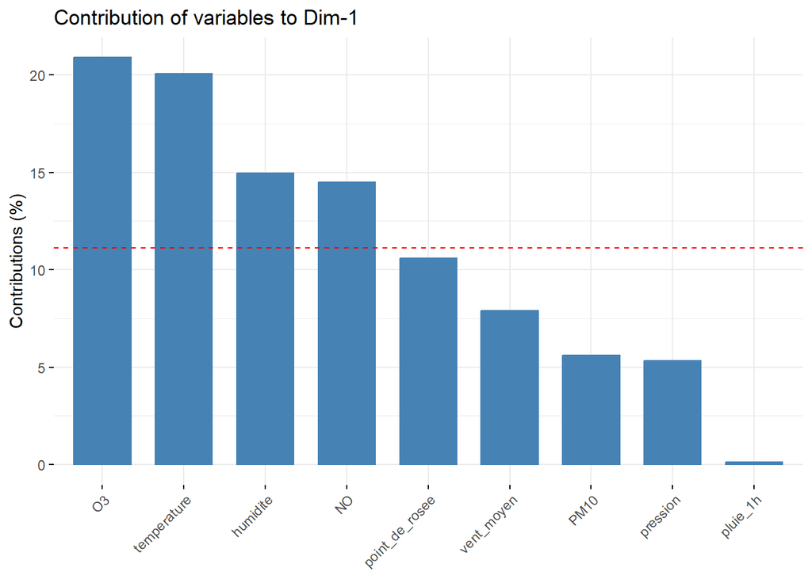

```r
fviz_contrib(pca_with_princip,choice="var",axes = 1)
```

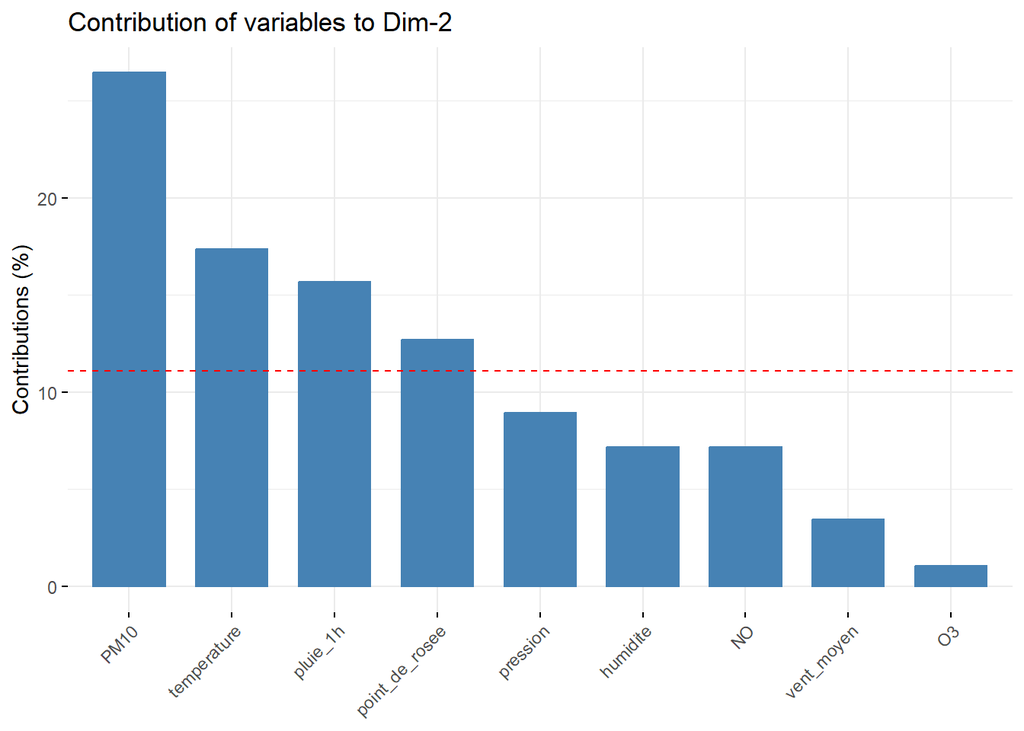

```r
fviz_contrib(pca_with_princip,choice="var",axes = 2)
```

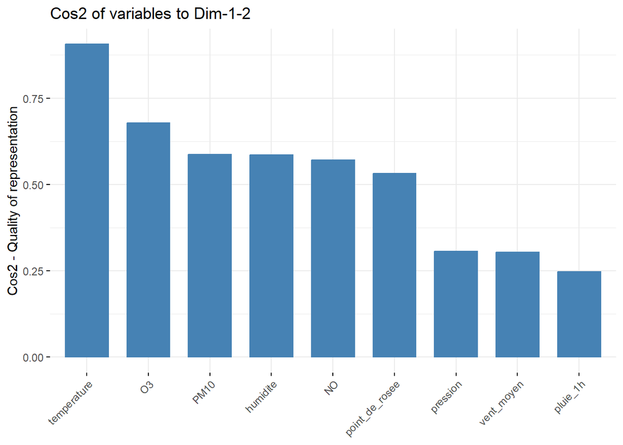

```r
fviz_cos2(pca_with_princip, choice="var", axes = c(1,2))
```

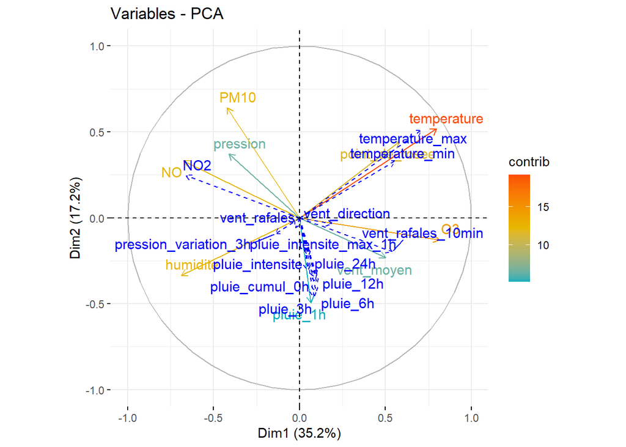

```r
# Réalisation de l'ACP avec toutes les variables
acp <- PCA(df_combine, scale.unit = TRUE, ncp = 5, graph = FALSE,
           quanti.sup = (ncol(df_principal) + 1):ncol(df_combine))

# Visualiser les variables principales (avec leurs contributions)
fviz_pca_var(acp, col.var = "contrib",
             gradient.cols = c("#00AFBB", "#E7B800", "#FC4E07"),
             repel = TRUE)
```

Contrairement à l’ACP complète, l’ACP avec une seule variable par groupe montre une dimension 1 beaucoup plus dominante, expliquant 35.21% de la variance, suivie de la dimension 2 avec 17.21%, pour un total cumulé de 52.42% sur les deux premières dimensions. Ce nombre est plus important que dans les cas précédent mais nous avons également beaucoup moins de variables. Avec le critère de Kaiser, nous conservons ici les 3 premières dimensions pour un pourcentage expliqué de 67.30%. Cette concentration de l’inertie sur les premières dimensions dans l’ACP simplifiée reflète une meilleure capacité à capter l’essentiel de l’information tout en simplifiant l’interprétation.

Cette différence montre que la réduction du nombre de variables par groupe permet de concentrer l’influence de certaines variables clés (pollution, température) sur les premières dimensions, tout en réduisant la dispersion causée par des variables redondantes.

Dans l’ACP simplifiée : - La dimension 1 reflète principalement la variabilité liée à la pollution atmosphérique (O3, NO) et à la température, permettant de l’interpréter comme un “axe de pollution et de climat”. - La dimension 2 capture des phénomènes liés aux précipitations (pluie_1h) et aux particules fines (PM10), et peut être interprétée comme un “axe précipitations et pollution particulaire”.

Dans l’ACP simplifiée, les variables non conservées dans les groupes, comme pression_variation_3h, vent_rafales, ou pluie_6h, sont intégrées comme variables supplémentaires. Ces variables n’ont pas d’impact direct sur la construction des dimensions, mais leur position dans le plan factoriel peut fournir des informations complémentaires sur leurs relations avec les variables principales. Ces variables supplémentaires permettent une analyse plus complète tout en maintenant une interprétation simplifiée des dimensions.

En conclusion, l’ACP simplifiée avec une seule variable par groupe offre une représentation plus concise et plus ciblée de l’information, tout en maintenant les autres variables comme supplémentaires pour enrichir l’analyse. En revanche, l’ACP complète est préférable si l’objectif est d’explorer toutes les interactions possibles entre les variables, même au sein des groupes similaires. Le choix entre ces deux approches dépend des objectifs de l’étude : compréhension détaillée ou interprétation simplifiée.

```r
#require(Factoshiny)
#res <- Factoshiny(df[,-c(1,2)])
```

**Problématique** **Quels sont les facteurs météorologiques les plus influents sur les niveaux de pollution atmosphérique (O3, NO, PM10), et comment ces relations varient-elles selon les heures de la journée et les jours de la semaine ?**

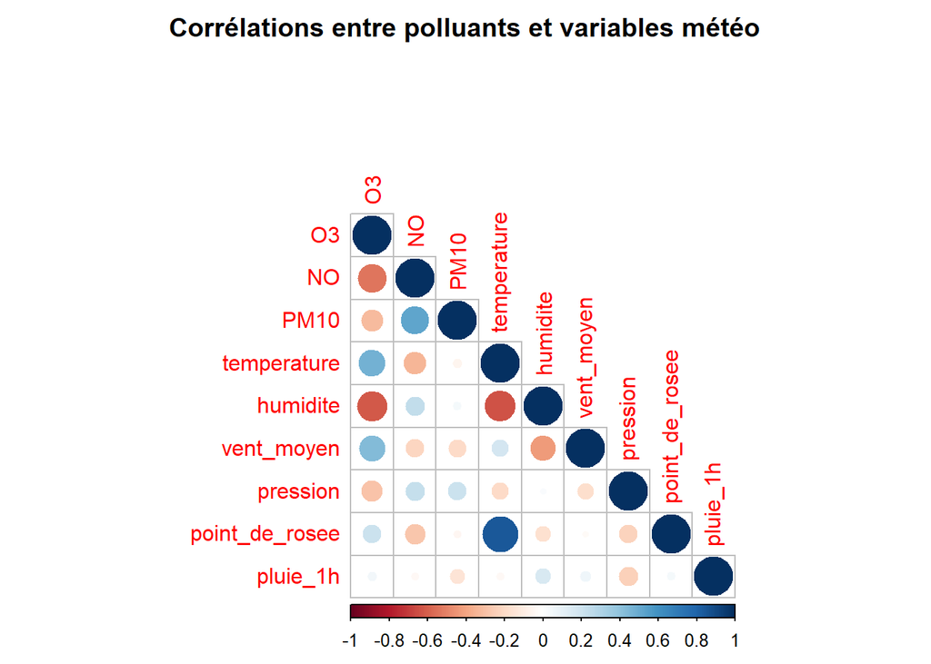

```r
# Sélection des variables pertinentes
pollution_vars <- df[, c("O3", "NO", "PM10")]
weather_vars <- df[, c("temperature", "humidite", "vent_moyen", "pression", "point_de_rosee", "pluie_1h")]

# Calcul des corrélations
cor_matrix <- cor(cbind(pollution_vars, weather_vars), use = "complete.obs")

# Visualisation de la matrice de corrélation
corrplot(cor_matrix, method = "circle", type = "lower",
         title = "Corrélations entre polluants et variables météo", mar = c(0, 0, 2, 0))
```

Nous pouvons voir que O3 semble corrélé assez fortement négativement avec NO et humidite, ce qui implique qu’un niveau élevé de NO ou d’humidité tendrait à donner un niveau assez bas de O3. Cela peut être du à une réaction chimique entre les deux élément pour le NO ou à la retombé des molécules d’O3 à cause de l’humidité. Dans un autre sens, O3 parait plutôt corrélé positivement avec temperature et vent_moyen. Ce qui implique que des températures élevées et un vent_moyen fort entraine un niveau d’O3 élevé égalemebt. NO et PM10 sont quant à eux assez corrélés positivement. On constate que point_de_rosee et temperature sont aussi fortement corrélés mais ce ne sera pas utile pour notre analyse.

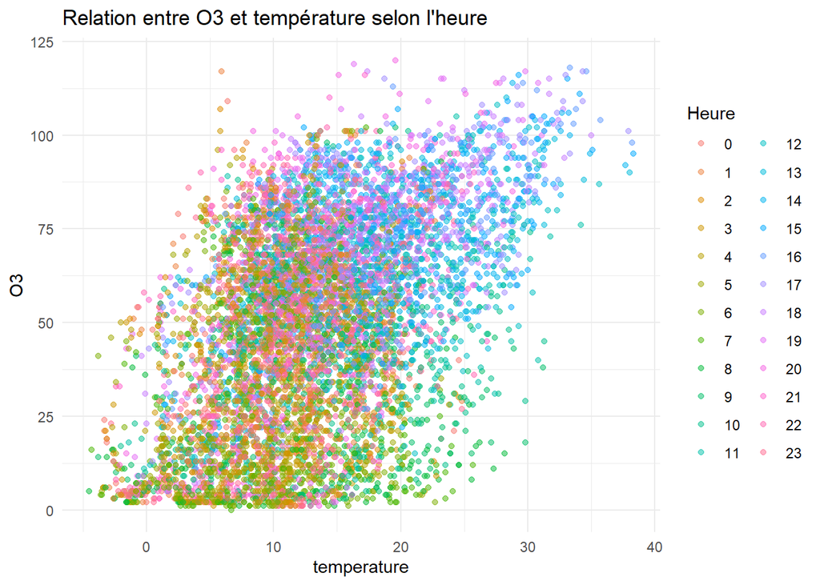

```r
# Exemple : Relation entre O3 et température par heure
ggplot(df, aes(x = temperature, y = O3, color = as.factor(heure))) +
  geom_point(alpha = 0.5) +
  ggtitle("Relation entre O3 et température selon l'heure") +
  theme_minimal() +
  labs(color = "Heure")
```

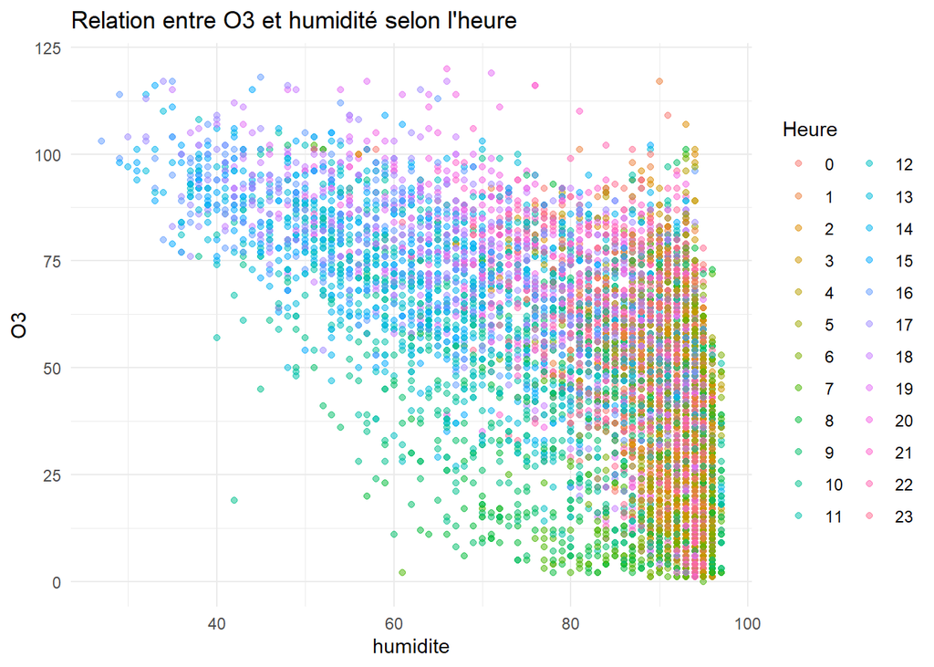

```r
# Exemple : Relation entre O3 et humidite par heure
ggplot(df, aes(x = humidite, y = O3, color = as.factor(heure))) +
  geom_point(alpha = 0.5) +
  ggtitle("Relation entre O3 et humidité selon l'heure") +
  theme_minimal() +
  labs(color = "Heure")
```

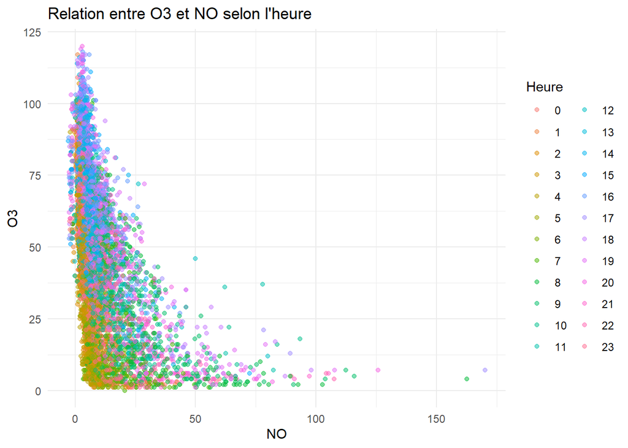

```r
# Exemple : Relation entre O3 et NO par heure
ggplot(df, aes(x = NO, y = O3, color = as.factor(heure))) +
  geom_point(alpha = 0.5) +
  ggtitle("Relation entre O3 et NO selon l'heure") +
  theme_minimal() +
  labs(color = "Heure")
```

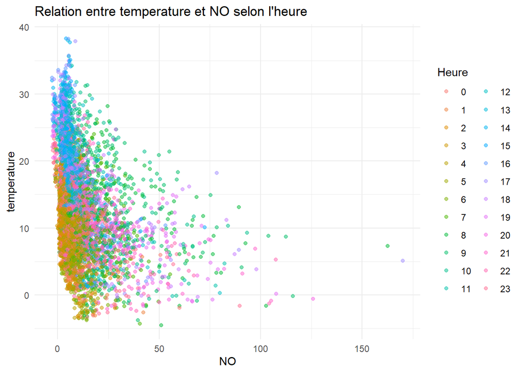

```r
# Exemple : Relation entre temperature et NO par heure
ggplot(df, aes(x = NO, y = temperature, color = as.factor(heure))) +
  geom_point(alpha = 0.5) +
  ggtitle("Relation entre temperature et NO selon l'heure") +
  theme_minimal() +
  labs(color = "Heure")
```

Il est assez difficile de se rendre compte précisément des valeurs car nous avons beaucoup d’observations. Cependant, nous pouvons voir que O3 et temperature semble effectivement lié plutôt positivement, de plus, il semblerait que pendant la nuit, le taux d’O3 soit plus faible, coïncidant avec le moment de la journée où les températures sont souvent plus froides ce qui est cohérent avec nos observations. Le taux augmente ensuite jusqu’à atteindre les heures les plus chaudes de la journée, puis il rediminue.